# Métodos computacionais para regressão quantílica

Bruno Santos

12/11/2020

## Carregando pacotes

```r
library(dplyr)
library(quantreg)
library(baquantreg)
library(bayesQR)
library(R2BayesX)
library(ggplot2)
```

## Gerando dados simulados

Primeiramente, geramos dados para poder simular os modelos. Nesse caso, geramos dados homocedásticos apenas a título de ilustração.

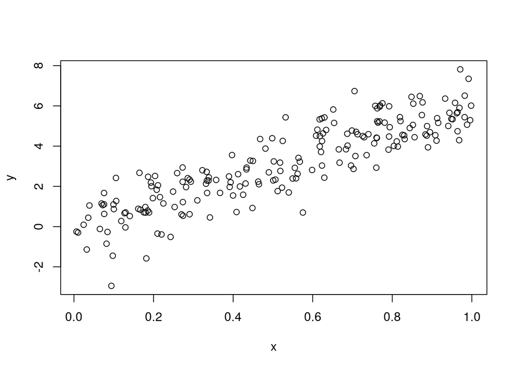

```r
## Dados simulados
n <- 200
x <- runif(n)
y <- 6 * x + rnorm(n, sd = 1)
dados_yx <- data.frame(x = x, y = y)
plot(x, y)
```

## Estimação por método frequentista

Podemos estimar o modelo pelo método frequentista utilizando a função `rq` do pacote `quantreg`. Podemos fazer o gráfico das estimativas utilizando a função `plot` junto com a função `summary`.

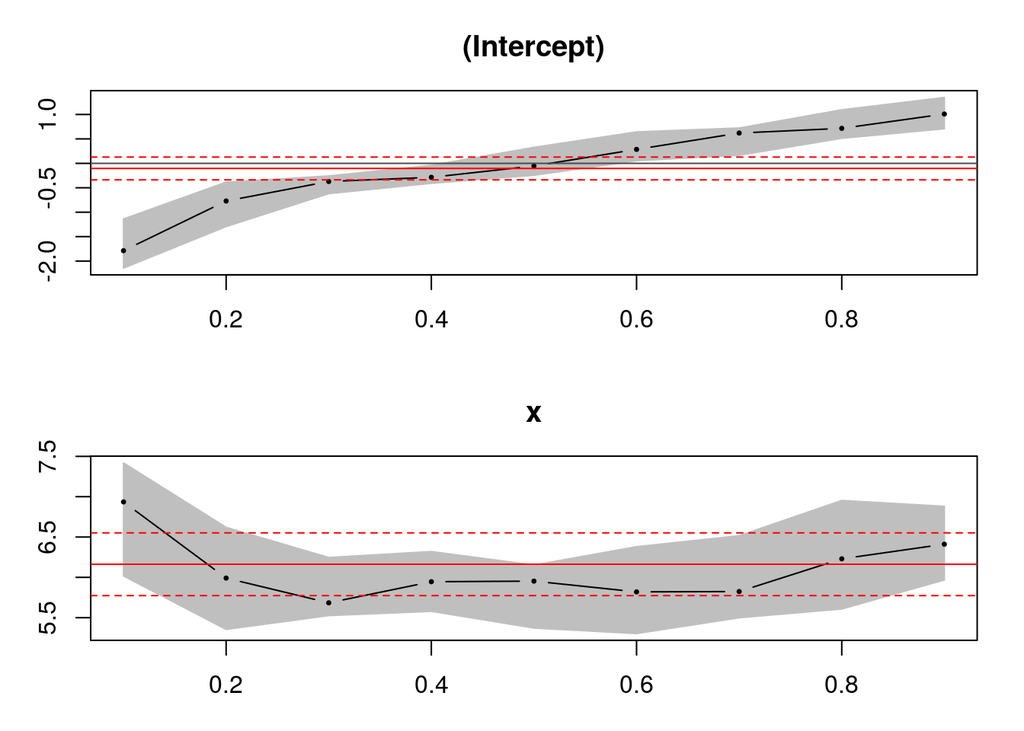

```r
model <- rq(y ~ x, tau = 1:9/10)
model %>%
  summary() %>%
  plot()
```

## Estimação pelo método bayesiano

### Pacote `baquantreg`

Primeiramente, consideramos o pacote `baquantreg` que pode ser obtido fazendo

```r
library(devtools)
install_github('brsantos/baquantreg')
```

A depender do tipo de modelo que vai ser ajustado diferentes pacotes podem ser considerados. Para ajustar o mesmo modelo que foi ajustado anteriormente e obter o gráfico das estimativas, podemos fazer

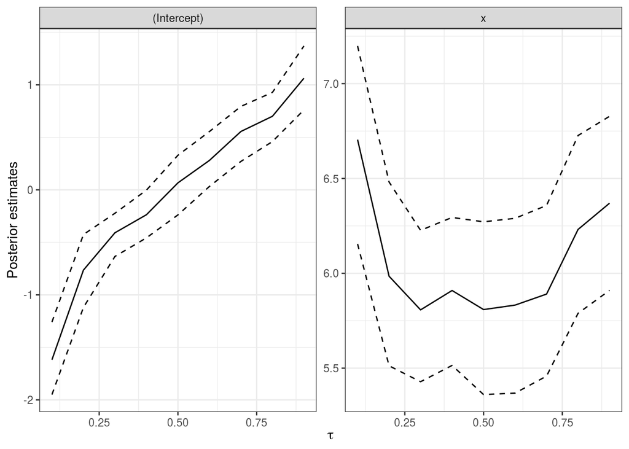

```r
model_bayes <- baquantreg::bayesQR(y ~ x, tau = 1:9/10,
                                   data = dados_yx,
                                   itNum = 2000)

model_bayes %>%
  summary() %>%
  plot()
```

A princípio a função `baquantreg::bayesQR` define os distribuições a priori para os parâmetros de forma não informativa. Para mais detalhes é só ver o help da função. Esse pacote deve ser utilizado somente se o número de observações for pequeno ou se o interesse estiver em estimar o modelo quando a variável resposta tem mais de uma dimensão.

### Pacote `bayesQR`

Um pacote que é um pouco mais eficiente com opções de utilizar métodos de seleção de variáveis como LASSO adaptativo, é o pacote `bayesQR`. Podemos estimar o mesmo modelo anterior e obter o resumo das estimativas fazendo

```r
# Método bayesiano com pacote bayesQR::bayesQR
model_bayes_bayesQR <- bayesQR::bayesQR(y ~ x,
                   data = dados_yx,
                   quantile = 1:9/10,
                   ndraw = 2000)
```

```r
summary(model_bayes_bayesQR)
```

```
##
## Type of dependent variable: continuous
## Lasso variable selection: no
## Normal approximation of posterior: yes
## Estimated quantile:  0.1
## Lower credible bound:  0.025
## Upper credible bound:  0.975
## Number of burnin draws:  0
## Number of retained draws:  2000
##
##
## Summary of the estimated beta:
##
##             Bayes Estimate lower  upper adj.lower adj.upper
## (Intercept)          -1.58 -2.44 -0.787     -4.34      1.17
## x                     6.62  5.39  7.837      2.88     10.35
##
##
## Type of dependent variable: continuous
## Lasso variable selection: no
## Normal approximation of posterior: yes
## Estimated quantile:  0.2
## Lower credible bound:  0.025
## Upper credible bound:  0.975
## Number of burnin draws:  0
## Number of retained draws:  2000
##
##
## Summary of the estimated beta:
##
##             Bayes Estimate lower  upper adj.lower adj.upper
## (Intercept)         -0.817 -1.46 -0.277     -2.74      1.10
## x                    6.038  5.18  6.950      3.36      8.72
##
##
## Type of dependent variable: continuous
## Lasso variable selection: no
## Normal approximation of posterior: yes
## Estimated quantile:  0.3
## Lower credible bound:  0.025
```

[output cut: 97 more lines]

```
## Type of dependent variable: continuous
## Lasso variable selection: no
## Normal approximation of posterior: yes
## Estimated quantile:  0.9
## Lower credible bound:  0.025
## Upper credible bound:  0.975
## Number of burnin draws:  0
## Number of retained draws:  2000
##
##
## Summary of the estimated beta:
##
##             Bayes Estimate lower upper adj.lower adj.upper
## (Intercept)           1.09 0.467  1.84    -0.767      2.95
## x                     6.36 5.236  7.53     3.377      9.33
```

É possível também gerar gráficos com esse pacote, porém as saídas não são tão boas e é preciso rodar a função seguinte diretamente no console.

```r
plot(model_bayes_bayesQR, plottype = 'quantile')
```

A função `bayesQR::bayesQR` também define valores para a distribuição a priori dos parâmetros de forma não informativa. Mais detalhes no help da função.

#### Usando LASSO na função `bayesQR::bayesQR`

Criando variável que não está relacionada com a resposta e ajustando o modelo com uma penalização lasso.

```r
dados_yx$x2 <- runif(n)

# Método bayesiano com pacote bayesQR::bayesQR
model_bayes_bayesQR2 <- bayesQR::bayesQR(y ~ x + x2,
                   data = dados_yx,
                   alasso = TRUE,
                   quantile = 1:9/10,
                   ndraw = 2000)
```

```r
summary(model_bayes_bayesQR2)
```

```
##
## Type of dependent variable: continuous
## Lasso variable selection: yes
## Normal approximation of posterior: yes
## Estimated quantile:  0.1
## Lower credible bound:  0.025
## Upper credible bound:  0.975
## Number of burnin draws:  0
## Number of retained draws:  2000
##
##
## Summary of the estimated beta:
##
##             Bayes Estimate lower upper adj.lower adj.upper
## (Intercept)         -1.379 -2.17 -0.32     -3.72     0.961
## x                    6.090  4.72  7.27      2.24     9.942
## x2                   0.237 -0.69  1.38     -2.22     2.699
##
##
## Type of dependent variable: continuous
## Lasso variable selection: yes
## Normal approximation of posterior: yes
## Estimated quantile:  0.2
## Lower credible bound:  0.025
## Upper credible bound:  0.975
## Number of burnin draws:  0
## Number of retained draws:  2000
##
##
## Summary of the estimated beta:
##
##             Bayes Estimate  lower   upper adj.lower adj.upper
## (Intercept)         -0.756 -1.704 -0.0279     -3.47      1.96
## x                    5.834  4.912  6.8814      2.43      9.24
## x2                   0.147 -0.443  1.0462     -1.42      1.71
##
##
## Type of dependent variable: continuous
## Lasso variable selection: yes
## Normal approximation of posterior: yes
```

[output cut: 106 more lines]

```
## Lasso variable selection: yes
## Normal approximation of posterior: yes
## Estimated quantile:  0.9
## Lower credible bound:  0.025
## Upper credible bound:  0.975
## Number of burnin draws:  0
## Number of retained draws:  2000
##
##
## Summary of the estimated beta:
##
##             Bayes Estimate  lower upper adj.lower adj.upper
## (Intercept)          1.186  0.308  2.84    -3.387      5.76
## x                    6.372  4.936  7.61     0.643     12.10
## x2                  -0.209 -1.550  0.64    -2.847      2.43
```

Podemos comparar sem utilizar a regularização pelo LASSO.

```r
# Método bayesiano com pacote bayesQR::bayesQR
model_bayes_bayesQR3 <- bayesQR::bayesQR(y ~ x + x2,
                   data = dados_yx,
                   alasso = FALSE,
                   quantile = 1:9/10,
                   ndraw = 2000)
```

[output not shown]

[output cut: 26 more lines]

[output not shown]

```r
summary(model_bayes_bayesQR3)
```

```
##
## Type of dependent variable: continuous
## Lasso variable selection: no
## Normal approximation of posterior: yes
## Estimated quantile:  0.1
## Lower credible bound:  0.025
## Upper credible bound:  0.975
## Number of burnin draws:  0
## Number of retained draws:  2000
##
##
## Summary of the estimated beta:
##
##             Bayes Estimate  lower  upper adj.lower adj.upper
## (Intercept)         -1.779 -2.632 -0.918     -4.08     0.526
## x                    6.364  5.266  7.581      2.85     9.875
## x2                   0.625 -0.624  1.772     -2.77     4.022
##
##
## Type of dependent variable: continuous
## Lasso variable selection: no
## Normal approximation of posterior: yes
## Estimated quantile:  0.2
## Lower credible bound:  0.025
## Upper credible bound:  0.975
## Number of burnin draws:  0
## Number of retained draws:  2000
##
##
## Summary of the estimated beta:
##
##             Bayes Estimate  lower upper adj.lower adj.upper
## (Intercept)         -1.058 -1.868 -0.32     -3.48      1.37
## x                    6.028  5.153  6.96      3.31      8.74
## x2                   0.433 -0.467  1.34     -2.07      2.94
##
##
## Type of dependent variable: continuous
## Lasso variable selection: no
## Normal approximation of posterior: yes
```

[output cut: 106 more lines]

```
## Lasso variable selection: no
## Normal approximation of posterior: yes
## Estimated quantile:  0.9
## Lower credible bound:  0.025
## Upper credible bound:  0.975
## Number of burnin draws:  0
## Number of retained draws:  2000
##
##
## Summary of the estimated beta:
##
##             Bayes Estimate lower upper adj.lower adj.upper
## (Intercept)          1.404  0.58 2.306     -0.95      3.76
## x                    6.271  5.06 7.392      3.16      9.38
## x2                  -0.559 -1.59 0.529     -3.23      2.11
```

Os intervalos de credibilidade são menores em torno do zero quando consideramos a penalização LASSO.

### Pacote `R2BayesX`

Uma terceira opção que apresenta boas soluções para modelos não lineares e também para estimação de modelos com efeitos aleatórios, o que pode ser útil para dados longitudinais, é o pacote `R2BayesX`. Porém, esse modelo precisa receber os argumentos referentes aos quantis de interesse de forma separada. Para estimar o modelo anterior considerando diferentes quantis, podemos fazer

```r
# Método bayesiano com bayesX
model_bayes_bayesx <- lapply(1:9/10, function(a){
  R2BayesX::bayesx(y ~ x,
                   data = dados_yx,
                   iter = 2000, burnin = 1000,
                   step = 1, method = "MCMC",
                   family = "quantreg", quantile = a)
})

lapply(model_bayes_bayesx, summary)
```

```
## [[1]]
## Call:
## R2BayesX::bayesx(formula = y ~ x, data = dados_yx, iter = 2000,
##     burnin = 1000, step = 1, method = "MCMC", family = "quantreg",
##     quantile = a)
##
## Fixed effects estimation results:
##
## Parametric coefficients:
##                Mean      Sd    2.5%     50%   97.5%
## (Intercept) -1.5910  0.1812 -1.9362 -1.5901 -1.2712
## x            6.6773  0.2570  6.1974  6.6661  7.1721
##
## Scale estimate:
##          Mean     Sd   2.5%    50%  97.5%
## Sigma2 0.3338 0.0228 0.2927 0.3326 0.3801
##
## N = 200  burnin = 1000  method = MCMC  family = quantreg
## iterations = 2000  step = 1
##
## [[2]]
## Call:
## R2BayesX::bayesx(formula = y ~ x, data = dados_yx, iter = 2000,
##     burnin = 1000, step = 1, method = "MCMC", family = "quantreg",
##     quantile = a)
##
## Fixed effects estimation results:
##
## Parametric coefficients:
##                Mean      Sd    2.5%     50%   97.5%
## (Intercept) -0.8630  0.1739 -1.2132 -0.8608 -0.5337
## x            6.1137  0.2440  5.6495  6.1058  6.5797
##
## Scale estimate:
##          Mean     Sd   2.5%    50%  97.5%
## Sigma2 0.5243 0.0369 0.4548 0.5230 0.6004
##
## N = 200  burnin = 1000  method = MCMC  family = quantreg
## iterations = 2000  step = 1
##
```

[output cut: 124 more lines]

```
##     quantile = a)
##
## Fixed effects estimation results:
##
## Parametric coefficients:
##               Mean     Sd   2.5%    50%  97.5%
## (Intercept) 1.1105 0.1255 0.8574 1.1110 1.3487
## x           6.3016 0.2020 5.9229 6.2982 6.7235
##
## Scale estimate:
##          Mean     Sd   2.5%    50%  97.5%
## Sigma2 0.3133 0.0221 0.2723 0.3123 0.3605
##
## N = 200  burnin = 1000  method = MCMC  family = quantreg
## iterations = 2000  step = 1
```

Para esse pacote, as opções de gráfico também são mais limitadas. Porém, é possível observar pelas estimativas que o modelo também retornou os valores esperados.

## Ajustando modelo considerando uma função não linear de x

Podemos considerar o pacote `R2BayesX` para ajustar modelos com função não lineares como efeito de `x`. Para isso, podemos criar dados em que a relação entre $Y$ e $X$ é uma função não linear. Podemos fazer o seguinte:

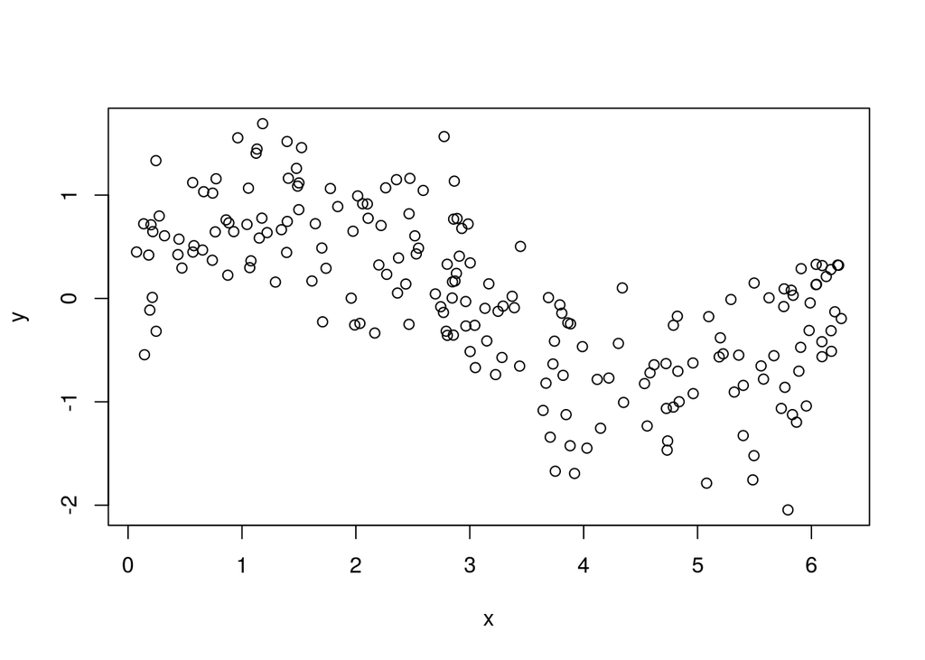

```r
n <- 200
x <- runif(n)*2*pi
y <-  sin(x) + rnorm(n, sd = 0.5)
dados_yx <- data.frame(x = x, y = y)
plot(x, y)
```

Nesse caso, estamos que a relação entre $Y$ e $X$ é definida pela função $sen(x)$ mais um erro aleatório.

Podemos ajustar o modelo não linear para a mediana

```r
modelo_mediana <- R2BayesX::bayesx(y ~ sx(x),
                 data = dados_yx,
                 iter = 11000, burnin = 1000,
                 step = 1, method = "MCMC",
                 family = "quantreg", quantile = 0.5)
```

E o resultado do ajuste pode ser visto fazendo

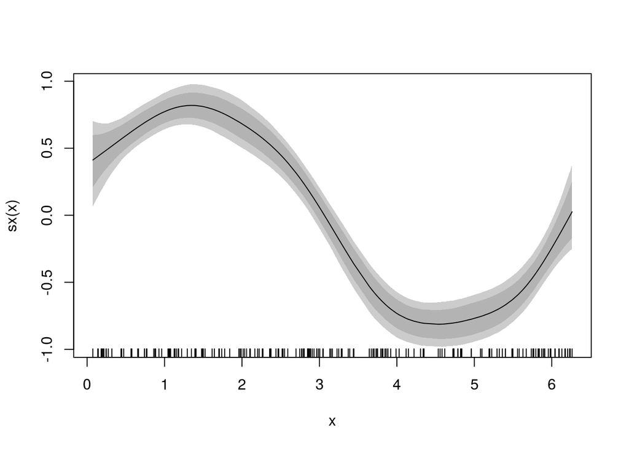

```r
fx <- fitted(modelo_mediana, term = "sx(x)")
plot(fx)
```

O default para o ajuste é considerar p-splines com o número de nós inicialmente igual a 20. Mais detalhes podem ser vistos verificando o help da função `R2BayesX::sx`. Também é possível observar o `summary` do ajuste.

```r
summary(modelo_mediana)
```

```
## Call:
## R2BayesX::bayesx(formula = y ~ sx(x), data = dados_yx, iter = 11000,
##     burnin = 1000, step = 1, method = "MCMC", family = "quantreg",
##     quantile = 0.5)
##
## Fixed effects estimation results:
##
## Parametric coefficients:
##                Mean      Sd    2.5%     50% 97.5%
## (Intercept) -0.0425  0.0362 -0.1138 -0.0425 0.028
##
## Smooth terms variances:
##         Mean     Sd   2.5%    50%  97.5%    Min    Max
## sx(x) 0.0270 0.0228 0.0060 0.0204 0.0878 0.0021 0.3877
##
## Scale estimate:
##          Mean     Sd   2.5%    50%  97.5%
## Sigma2 0.1371 0.0097 0.1192 0.1367 0.1576
##
## N = 200  burnin = 1000  method = MCMC  family = quantreg
## iterations = 11000  step = 1
```

Poderíamos também ajustar o modelo para outros quantis:

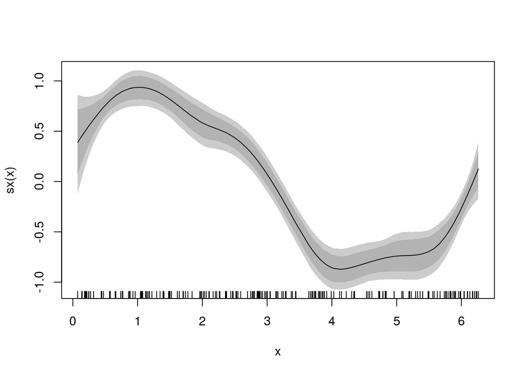

```r
modelo_1quartil <- R2BayesX::bayesx(y ~ sx(x),
                                    data = dados_yx,
                                    iter = 11000, burnin = 1000,
                                    step = 1, method = "MCMC",
                                    family = "quantreg", quantile = 0.25)
plot(fitted(modelo_1quartil, term = "sx(x)"))
```

## Ajuste para dados longitudinais

Primeiramente, podemos gerar valores que tenham uma certa característica de dados longitudinais.

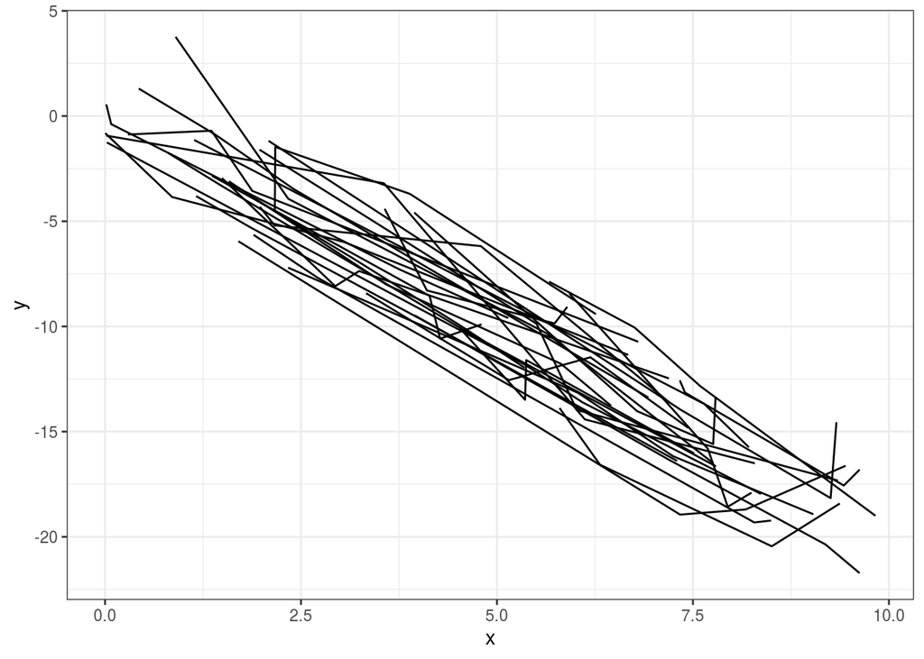

```r
## Gerando dados longitudinais
set.seed(42)
individuo <- 1:30
obs_ind <- 4
efeito_aleatorio <- rnorm(length(individuo), sd = 1)
x <- lapply(individuo, function(a) runif(obs_ind, 0, 10))
y <- lapply(1:length(x), function(a) -2 * x[[a]] + efeito_aleatorio[a])

x <- unlist(x)
y <- unlist(y) + rnorm(length(individuo * obs_ind), sd = 1.5)

data_longitudinal <- data.frame(y = y,
                                x = x,
                                id = rep(individuo, each = obs_ind))

ggplot(data_longitudinal) + theme_bw() +
  aes(x = x, y = y, group = id) +
  geom_line()
```

Em seguida, podemos ajustar o modelo de regressão quantílica bayesiano para dados logitudinais, considerando um intercepto aleatório para as diferentes pessoas (`id`)

```r
## Ajustando modelo para dados longitudinais
modelo_mediana_long <- R2BayesX::bayesx(y ~ x + sx(id, bs = "re"),
                                    data = data_longitudinal,
                                    iter = 11000, burnin = 1000,
                                    step = 1, method = "MCMC",
                                    family = "quantreg", quantile = 0.5)
summary(modelo_mediana_long)
```

```
## Call:
## R2BayesX::bayesx(formula = y ~ x + sx(id, bs = "re"), data = data_longitudinal,
##     iter = 11000, burnin = 1000, step = 1, method = "MCMC", family = "quantreg",
##     quantile = 0.5)
##
## Fixed effects estimation results:
##
## Parametric coefficients:
##                Mean      Sd    2.5%     50%  97.5%
## (Intercept)  0.5250 49.7672 -7.1297  0.0818  8.344
## x           -2.0128  1.2166 -2.2758 -2.0109 -1.740
##
## Random effects variances:
##                 Mean         Sd       2.5%        50%      97.5%        Min
## sx(id):re 2.1218e+04 1.1692e+06 3.1820e-01 2.9520e+00 1.9081e+03 4.5400e-02
##                Max
## sx(id):re 93579700
##
## Scale estimate:
##           Mean      Sd    2.5%     50%  97.5%
## Sigma2 13.3160 98.9019  3.3794  4.7969 56.823
##
## N = 120  burnin = 1000  method = MCMC  family = quantreg
## iterations = 11000  step = 1
```

É possível ver se os efeitos aleatórios obtidos se aproximam daqueles gerados inicialmente fazendo

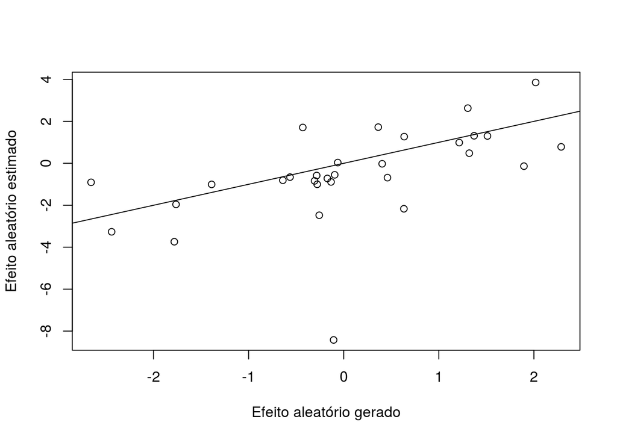

```r
plot(fitted(modelo_mediana_long, term = "sx(id):re")$Mean ~ efeito_aleatorio,
     ylab = "Efeito aleatório estimado",
     xlab = "Efeito aleatório gerado")
abline(0, 1)
```

Mais informações e detalhes do pacote `R2BayesX` podem ser vistos no [link](https://www.jstatsoft.org/article/view/v063i21).

## Modelo de regressão quantílica para dados multivariados

Primeiramente, gerando os dados de dimensão 2.

```r
set.seed(42)
y1 <- runif(n)
y2 <- runif(n)

x1 <- runif(n)

data_model <- data.frame(y1, y2, x1)

modelos <-
  baquantreg:::multBayesQR(c("y1", "y2"), ~ x1,
                          directionPoint = 99,
                          tau = c(0.2, 0.3), dataFile = data_model,
                          itNum = 11000, burnin = 1000,
                          outfile = '~/arquivos_temporarios/')
```

É importante definir o argumento `outfile` para depois utilizar os valores obtidos, caso o programa dê erro no meio.

Para desenhar as regiões quantílicas, você deve usar a função `baquantreg:::drawQuantileRegion`. É importante entender o papel do argumento `ngridpoints`.

```r
x_value <- c(1, 0)
baquantreg:::drawQuantileRegion(modelos, ngridpoints = 100,
                                xValue = x_value,
                                painted = FALSE, comparison = TRUE)
```

Para o caso de três dimensões, o programa ainda não faz o desenho automaticamente. Primeiramente para obter o modelo é o mesmo programa anterior com

```r
set.seed(123)
n <- 600

y1 <- runif(n)
y2 <- runif(n)
y3 <- runif(n)

x1 <- runif(n)
x2 <- runif(n)
x3 <- runif(n)

data_model <- data.frame(y1, y2, y3, x1, x2, x3)

modelos_3d <-
  baquantreg:::multBayesQR(c("y1", "y2", "y3"), ~ x1 + x2 + x3,
                          directionPoint = 3,
                          tau = c(0.2, 0.3), dataFile = data_model,
                          itNum = 11000, burnin = 1000,
                          outfile = '~/arquivos_temporarios')
```

Depois para obter as regiões quantílicas é preciso fazer alguns passos

```r
x1_0 =  c(1, 0, 0, 0)
x1_1 = c(1, 1, 0, 0)

path_folder <- '~/arquivos_temporarios'

## Function to get quantile regions for groups of points.
get_points_comparison <- function(list_xvalues, n_points = 100){
  lapply(list_xvalues, function(value_list){
    baquantreg:::drawQuantileRegion_3D(ngridpoints = n_points,
                                       datafile = data_model,
                                       response = c("y1", "y2", "y3"),
                                       xValue = value_list,
                                       result_folder = TRUE,
                                       path_folder = path_folder)
  })
}

points_comparison <- get_points_comparison(list(x_1, x_2))


### Function using plot3D::lines3D

alpha_test <- 0.2
line_width <- 0.5

draw_conditional_lines3D <- function(points, name_var, tau_vector){

  n_tau = length(tau_vector)
  angles_theta <- 0:2*45

  lapply(1:n_tau, function(bb){
    lapply(angles_theta, function(a){
      par(mar = c(7, 7, 1, 1))
      plot3D::lines3D(x = points[[1]][[bb]]$y1,
                      y = points[[1]][[bb]]$y2,
                      z = points[[1]][[bb]]$y3,
                      xlab = "y1", ylab = 'y2', zlab = 'y3',
                      phi = 10,
                      theta = a,
                      col = '#9E0142',
                      alpha = alpha_test,
                      lwd = line_width,
                      main = paste0('Tau = ', tau_vector[bb]),
                      ticktype = "detailed",
                      bty = "g",
                      nticks = 3,
                      cex.axis = 1)

      plot3D::lines3D(x = points[[2]][[bb]]$y1,
                      y = points[[2]][[bb]]$y2,
                      z = points[[2]][[bb]]$y3,
                      col = '#5E4FA2',
                      lwd = line_width,
                      alpha = alpha_test, add = TRUE)
    })
  })
}

draw_conditional_lines3D(points_comparison,
                         'x1', c(0.2, 0.3))
```